# DataLab Cup 1: Predicting Appropriate Response

Shan-Hung Wu & DataLab  
Fall 2018

```python
%matplotlib inline
```

# Competition Info

In this competition, you have to **select the most appropriate response from 6 candidates** based on previous chat message. You are provided with lines of total 8 tv programs as training data, and each program has serveral episodes. You also get a question collection which contains **1 chat history and 6 condidate responses** for each question. Your goal is to learn a function that is able to predict the best response.

[figure not shown]

### Dataset Format

- `Program01.csv~Program08.csv` contains total 8 tv program's lines.
- `Question.csv` contains total 500 questions, and each question includes chat and candidate options.

### How to Submit Results?

You have to predict the correct response in `Question.csv`, and **submit it to the Kaggle-In-Class** online judge system. Following are some example actions:

| Action | Description |
| --- | --- |
| Data | Get the dataset. |
| Make a Submission | Your testing performance will be evaluated immediately and shown on the leaderboard. |
| Leaderboard | The current ranking of participants. Note that this ranking only reflects the performance on part of the testset and may not equal to the final ranking (see below). |
| Forum | You can ask questions or share findings here. |
| Kernels | You can create your jupyter notebook, run it, and keep it as private or public here. |

**Note**: You can only submit 20 submissions per UTC day.

### Scoring

The evaluation metric is **CategorizationAccuracy**. The ranking shown on the leaderboard before the end of competition reflects only the accuracy over **50% of** `Question.csv`. However, this is **not** how we evaluate your final scores. After the competition, we combine **accuracy over the rest `Question.csv`** and **your report** as the final score.  
There will be two baseline results, namely, `Benchmark-60` and `Benchmark-80`. You have to outperform `Benchmark-60` to get 60 points, and `Benchmark-80` to get 80. Meanwhile, **the higher accuracy you achieve, the higher the final score you will get**.

### Honor code

In addition to the behaviors outlined by the official competition rules, "cheating" encompasses any attempt to gain an edge in accuracy by using information that is outside of the provided dataset, or an attempt to use the provided information in a way that is not intended ,or attempt to copy code from other teams. Examples of cheating include (but are not limited to):

- Attempting to use datasets and references beyond those made available by the competition
- Attempting to abuse the competition infrastructure to gain an edge
- Attempting to copy code from other teams

Your team will get 0 score in this competition once being found out cheating.

### Important Dates

- 2018/10/16 (TUE) - competition starts
- 2018/10/28 (SUN) 23:59pm - competition ends, final score announcement
- 2018/10/30 (TUE) - winner team share (not determined)
- 2018/11/01 (THU) 23:59pm - report submission (iLMS)

### Report

After the competition, **each team have to hand in a report** in Jupyter notebook format via the iLMS system. You report should include:

- Student ID, name of each team member
- How did you preprocess data (cleaning, feature engineering, etc.)?
- How did you build the classifier (model, training algorithm, special techniques, etc.)?
- Conclusions (interesting findings, pitfalls, takeaway lessons, etc.)?

The file name of your report must be `DL_comp1_{Your Team number}_report.ipynb`.

# Hint 1: Feature Engineering is More Important Then You Expected

So far, we learn various machine learning techniques based on datasets where the date features are predefined. In many real-world applications, including this competition, we only get raw data and have to define the features ourself. **Feature engineering** is the process of using domain knowledge to create features that make machine learning algorithms work. While good modeling and training techniques help you make better predictions, feature engineering usually determines whether your task is "learnable".

```python
import pandas as pd

NUM_PROGRAM = 8
programs = []
for i in range(1, NUM_PROGRAM+1):
    program = pd.read_csv('Program0%d.csv' % (i))

    print('Program %d' % (i))
    print('Episodes: %d' % (len(program)))
    print(program.columns)
    print()

    print(program.loc[:1]['Content'])
    print()

    programs.append(program)
```

```
Program 1
Episodes: 1299
Index(['Content'], dtype='object')

0    還好天氣不錯\n昨天晚上的流星雨\n我看到很多流星\n這次的收穫真豐富\n當然豐富啦\n我就...
1    好熱喔\n這種倉庫很不通風\n好熱喔\n受不了\n今天天氣真的是太熱了\n我都快中暑了\n那...
Name: Content, dtype: object

Program 2
Episodes: 205
Index(['Content'], dtype='object')

0    我們現在只差兩分\n只差兩分\n等下阿偉先站過來\n他們會埋伏一個射手出來\n我們盡量把他堵...
1    四十年前\n我媽為了養我跟我哥\n開這間理髮店\n她把手藝都傳給哥\n希望他可以接下這間店\...
Name: Content, dtype: object

Program 3
Episodes: 57
Index(['Content'], dtype='object')

0    台南人劇團\n一個從古都台南輸出的\n現代劇團\n每年總有令人驚奇的戲劇產生\n玩大師\n莎...
1    一齣舞台劇\n這個舞台劇的結果\n所有觀眾都知道\n兩個演員在舞台上\n撐了一百多分鐘\n目...
Name: Content, dtype: object

Program 4
Episodes: 10
Index(['Content'], dtype='object')

0    念書幹嘛偷光\n燈一開就有了啊\n太陽是不是從樹葉之間的\n這個縫灑下來\n然後在地上啊\n...
1    倫語社\n效果立竿見影\n立竿見影\n這也是指很快囉\n但是它和曇花一現\n有什麼不一樣\n...
Name: Content, dtype: object

Program 5
Episodes: 369
Index(['Content'], dtype='object')

0    公平的對待\n孩子才會樂於做良性的競爭\n這樣一來\n真正有實力的人才不會被埋沒\n老師好\...
1    你們看\n我臉上的痘痘\n畫了粧之後就沒那麼明顯了\n就算熬夜K書\n長了黑眼圈也不怕\n你...
Name: Content, dtype: object

```

[output cut: 8 more lines]

```
Program 7
Episodes: 611
Index(['Content'], dtype='object')

0    嗨, 大家好\n歡迎收看「聽聽看」\n你這個禮拜過得好不好呢\n有沒有什麼新鮮事\n要和朋友...
1    你今天是不是跟我一樣\n早就迫不及待的\n想要收看我們「聽聽看」了呢\n怎麼樣\n上個禮拜的...
Name: Content, dtype: object

Program 8
Episodes: 210
Index(['Content'], dtype='object')

0    每天帶你拜訪一個家庭\n邀請一位貴賓和他們共進晚餐\n談談人生大小事\n但如果登門拜訪的\n...
1    如果用一句話\n來形容吃飯這件事情\n那句話應該就是體驗人生\n今天的「誰來晚餐」\n發生在...
Name: Content, dtype: object
```

```python
questions = pd.read_csv('Question.csv')

print('Question')
print('Episodes: %d' % (len(questions)))
print(questions.columns)
print()

print(questions.loc[:2]['Question'])
print()

for i in range(6):
    print(questions.loc[:2]['Option%d' % (i)])
    print()
```

```
Question
Episodes: 500
Index(['Question', 'Option0', 'Option1', 'Option2', 'Option3', 'Option4',
       'Option5'],
      dtype='object')

0    媽給你送錢包來啦 來 你看一下是不是這個\n對 就是這個 你在哪裡找到它的\n
1             古人說三日不讀書 面目可憎 我覺得我最近可能臉色太難看了\n
2                         你說我們做父母的最擔心的就是這個\n
Name: Question, dtype: object

0        你看 這是我新買的錢包
1    所以想回復我昔日面貌姣好的樣子
2      我剛剛聽你媽說你要讀什麼科
Name: Option0, dtype: object

0     我的錢包不見了啦
1    是不是要定期來舉辦
2    其他老師又集體叛變
Name: Option1, dtype: object

0    以後上網咖的錢包在我身上
1         各辦理一次才對
2        聽起來好好玩天啊
Name: Option2, dtype: object

0                          什麼有錢包場
1                     能夠督促所有的用人機關
2    只是小孩自己的興趣不能得到發展 他們的心裡可能也會很悶喔
Name: Option3, dtype: object

0    早上你爸爸在車上找到的 一定是前天你放學的時候掉在車上了
1                   在上次的節目討論中也有提到
2                      走到這裡就沒有路了耶
Name: Option4, dtype: object

0         我為什麼要給你們錢包
1           超過九十分貝以上
2    每一個科目像是國語數學都很優秀
Name: Option5, dtype: object
```

We get raw content of programs' lines, but there aren't any feature we can learn from. To predict from text, we have to go through several preprocessing steps first.

### Preprocessing: Cut Words

Since chinese characters are continuous one by one, we have to **cut them into meaningful words** first. We use jieba with **traditional chinese dictionary** to cut our text. You can install **jieba** via pip.

```
    pip install jieba
```

```python
import jieba

jieba.set_dictionary('big5_dict.txt')
```

```python
example_str = '我討厭吃蘋果'
cut_example_str = jieba.lcut(example_str)
print(cut_example_str)
```

```
Building prefix dict from C:\Users\User\Desktop\DataLab\CS 565600\Competition 01\Comp01\big5_dict.txt ...
Loading model from cache C:\Users\User\AppData\Local\Temp\jieba.ube8fe9c3061f8c5e229c09e69d35a940.cache
Loading model cost 0.539 seconds.
Prefix dict has been built succesfully.
```

```
['我', '討厭', '吃', '蘋果']
```

We cut not only `Program.csv` but also `Question.csv`, and save as **list**.

```python
def jieba_lines(lines):
    cut_lines = []

    for line in lines:
        cut_line = jieba.lcut(line)
        cut_lines.append(cut_line)

    return cut_lines
```

```python
cut_programs = []

for program in programs:
    episodes = len(program)
    cut_program = []

    for episode in range(episodes):
        lines = program.loc[episode]['Content'].split('\n')
        cut_program.append(jieba_lines(lines))

    cut_programs.append(cut_program)
```

```python
print("%d programs" % len(cut_programs))
print("%d episodes in program 0" % len(cut_programs[0]))
print("%d lines in first episode of program 0" % len(cut_programs[0][0]))

print()
print("first 3 lines in 1st episode of program 0: ")
print(cut_programs[0][0][:3])
```

```
8 programs
1299 episodes in program 0
635 lines in first episode of program 0

first 3 lines in 1st episode of program 0:
[['還好', '天氣', '不錯'], ['昨天', '晚上', '的', '流星雨'], ['我', '看到', '很多', '流星']]
```

```python
cut_questions = []
n = len(questions)

for i in range(n):
    cut_question = []
    lines = questions.loc[i]['Question'].split('\n')
    cut_question.append(jieba_lines(lines))

    for j in range(6):
        line = questions.loc[i]['Option%d' % (j)]
        cut_question.append(jieba.lcut(line))

    cut_questions.append(cut_question)
```

```python
print("%d questions" % len(cut_questions))
print(len(cut_questions[0]))

# 1 question
print(cut_questions[0][0])

# 6 optional reponses
for i in range(1, 7):
    print(cut_questions[0][i])
```

```
500 questions
7
[['媽給', '你', '送', '錢包', '來', '啦', ' ', '來', ' ', '你', '看', '一下', '是', '不', '是', '這個'], ['對', ' ', '就是', '這個', ' ', '你', '在', '哪裡', '找到', '它', '的'], []]
['你', '看', ' ', '這是', '我', '新', '買', '的', '錢包']
['我', '的', '錢包', '不見了', '啦']
['以後', '上', '網咖', '的', '錢包', '在', '我', '身上']
['什麼', '有', '錢包', '場']
['早上', '你', '爸爸', '在', '車上', '找到', '的', ' ', '一定', '是', '前天', '你', '放學', '的', '時候', '掉', '在', '車上', '了']
['我', '為什麼', '要給', '你們', '錢包']
```

```python
import numpy as np

np.save('cut_Programs.npy', cut_programs)
np.save('cut_Questions.npy', cut_questions)
```

After saving, we can load them directly next time.

```python
cut_programs = np.load('cut_Programs.npy')
cut_Question = np.load('cut_Questions.npy')
```

### Preprocessing: Word Dictionary & Out-of-Vocabulary

There are many words after cutting, but **not all of them are useful**. The words **too common or too rare** can not give us information but may introduce noise. We count the the number of occurrence for each word and remove useless one.

```python
word_dict = dict()
```

```python
def add_word_dict(w):
    if not w in word_dict:
        word_dict[w] = 1
    else:
        word_dict[w] += 1
```

```python
for program in cut_programs:
    for lines in program:
        for line in lines:
            for w in line:
                add_word_dict(w)
```

```python
for question in cut_questions:
    lines = question[0]
    for line in lines:
        for w in line:
            add_word_dict(w)

    for i in range(1, 7):
        line = question[i]
        for w in line:
            add_word_dict(w)
```

```python
import operator

word_dict = sorted(word_dict.items(), key=operator.itemgetter(1), reverse=True)
print("Total %d words in word_dict" % len(word_dict))
```

```
Total 174420 words in word_dict
```

```python
VOC_SIZE = 15000
VOC_START = 20

voc_dict = word_dict[VOC_START:VOC_START+VOC_SIZE]
print(voc_dict[:10])
print()
print("Total %d words in voc_dict" % len(voc_dict))
np.save('voc_dict.npy', voc_dict)
```

```
[('他', 81632), ('也', 77206), ('就是', 75579), ('說', 74281), ('來', 68735), ('會', 67933), ('那', 66863), ('喔', 61530), ('可以', 60268), ('跟', 60056)]

Total 15000 words in voc_dict
```

```python
voc_dict = np.load('voc_dict.npy')
```

Now, `voc_dict` becomes better word dictionary, then we should replace those removed words aka out-of-vocabulary words into an **unknown token** in the following use.

### Preprocessing: Generating Training Data

Though the format of question is to select one from six, our traing data only have continuous lines. Naively, I want to change the whole problem **into a binary classification** which means given two lines, my model want to **judge these two are context or not**.

```python
import random

NUM_TRAIN = 10000
TRAIN_VALID_RATE = 0.7
```

```python
def generate_training_data():
    Xs, Ys = [], []

    for i in range(NUM_TRAIN):
        pos_or_neg = random.randint(0, 1)

        if pos_or_neg==1:
            program_id = random.randint(0, NUM_PROGRAM-1)
            episode_id = random.randint(0, len(cut_programs[program_id])-1)
            line_id = random.randint(0, len(cut_programs[program_id][episode_id])-2)

            Xs.append([cut_programs[program_id][episode_id][line_id],
                       cut_programs[program_id][episode_id][line_id+1]])
            Ys.append(1)

        else:
            first_program_id = random.randint(0, NUM_PROGRAM-1)
            first_episode_id = random.randint(0, len(cut_programs[first_program_id])-1)
            first_line_id = random.randint(0, len(cut_programs[first_program_id][first_episode_id])-1)

            second_program_id = random.randint(0, NUM_PROGRAM-1)
            second_episode_id = random.randint(0, len(cut_programs[second_program_id])-1)
            second_line_id = random.randint(0, len(cut_programs[second_program_id][second_episode_id])-1)

            Xs.append([cut_programs[first_program_id][first_episode_id][first_line_id],
                       cut_programs[second_program_id][second_episode_id][second_line_id]])
            Ys.append(0)

    return Xs, Ys
```

```python
Xs, Ys = generate_training_data()

x_train, y_train = Xs[:int(NUM_TRAIN*TRAIN_VALID_RATE)], Ys[:int(NUM_TRAIN*TRAIN_VALID_RATE)]
x_valid, y_valid = Xs[int(NUM_TRAIN*TRAIN_VALID_RATE):], Ys[int(NUM_TRAIN*TRAIN_VALID_RATE):]
```

Since machine learning models only accept numerical features, we must convert categorical features, such as tokens into a numerical form. In the next section, we introduce several commonly used models, including **BoW**, **TF-IDF**, and **Feature Hashing** that allows us to represent text as numerical feature vectors.

```python
example_doc = []

# lines in 1st episode in program 0
for line in cut_programs[0][0]:
    example_line = ''
    for w in line:
        if w in voc_dict:
            example_line += w+' '

    example_doc.append(example_line)

print(example_doc[:10])
```

```
['還好 天氣 不錯 ', '昨天 晚上 ', '看到 很多 流星 ', '這次 收穫 真 豐富 ', '當然 豐富 啦 ', '說 嘛 ', '精心 製作 ', '被 一個 人 吃掉 ', '真的 嗎 ', '不要 忘記 做 秘密 檔案 ']
```

### Word2Vec: BoW (Bag-Of-Words)

The idea behind bag-of-words model is to represent each document by occurrence of words, which can be summarized as the following steps:

1. Build vocabulary dictionary by unique token from the entire set of documents;
2. Represent each document by a vector, where each position corresponds to the occurrence of a vocabulary in dictionary.

Each vocabulary in BoW can be a single word (1-gram) or a sequence of n continuous words (n-gram). It has been shown empirically that 3-gram or 4-gram BoW models yield good performance in anti-spam email filtering application.  
Here, we use Scikit-learn's implementation [CountVectorizer](http://scikit-learn.org/stable/modules/generated/sklearn.feature_extraction.text.CountVectorizer.html) to construct the BoW model:

```python
import scipy as sp
from sklearn.feature_extraction.text import CountVectorizer

# ngram_range=(min, max), default: 1-gram => (1, 1)
count = CountVectorizer(ngram_range=(1, 1))

count.fit(example_doc)
BoW = count.vocabulary_
print('[vocabulary]\n')
for key in list(BoW.keys())[:10]:
    print('%s %d' % (key, BoW[key]))
```

```
[vocabulary]

還好 469
天氣 168
不錯 46
昨天 268
晚上 270
看到 352
很多 217
流星 310
這次 456
收穫 259
```

The parameter `ngram_range=(min-length, max-length)` in CountVectorizer specifies the vocabulary to be `{min-length}`-gram to `{max-length}`-gram. For example `ngram_range=(1, 2)` will use both 1-gram and 2-gram as vocabularies. After constructing BoW model by calling `fit()`, you can access BoW vocabularies in its attribute `vocubalary_`, which is stored as Python dictionary that maps vocabulary to an integer index.  
Let's transform the example documents into feature vectors:

```python
# get matrix (line_id, vocabulary_id) --> (this vocabulary occurs how many times in this line)
doc_bag = count.transform(example_doc)
print(' (lid, vid)     tf')
print(doc_bag[:10])

print('\nIs document-term matrix a scipy.sparse matrix? {}'.format(sp.sparse.issparse(doc_bag)))
```

```
 (lid, vid)     tf
  (0, 46)	1
  (0, 168)	1
  (0, 469)	1
  (1, 268)	1
  (1, 270)	1
  (2, 217)	1
  (2, 310)	1
  (2, 352)	1
  (3, 259)	1
  (3, 435)	1
  (3, 456)	1
  (4, 340)	1
  (4, 435)	1
  (6, 370)	1
  (6, 414)	1
  (7, 6)	1
  (7, 128)	1
  (8, 354)	1
  (9, 44)	1
  (9, 225)	1
  (9, 293)	1
  (9, 361)	1

Is document-term matrix a scipy.sparse matrix? True
```

Since each document contains only a small subset of vocabularies, `CountVectorizer.transform()` stores feature vectors as scipy.sparse matrix, where entry index is `(line-index, vocabulary-index)` pair, and the value is the **term frequency**---the number of times a vocabulary (term) occurs in a document.  
Unfortunately, many Scikit-learn classifiers do not support input as sparse matrix now. We can convert `doc_bag` into a Numpy dense matrix:

```python
doc_bag = doc_bag.toarray()
print(doc_bag[:10])

print('\nAfter calling .toarray(), is it a scipy.sparse matrix? {}'.format(sp.sparse.issparse(doc_bag)))
```

```
[[0 0 0 ... 0 0 0]
 [0 0 0 ... 0 0 0]
 [0 0 0 ... 0 0 0]
 ...
 [0 0 0 ... 0 0 0]
 [0 0 0 ... 0 0 0]
 [0 0 0 ... 0 0 0]]

After calling .toarray(), is it a scipy.sparse matrix? False
```

```python
doc_bag = count.fit_transform(example_doc).toarray()

print("[most frequent vocabularies]")

# conpute how many times each word occurs in doc_bag
bag_cnts = np.sum(doc_bag, axis=0)

# get words occur in doc_bag
words_num = bag_cnts.shape[0]
ones_vector = np.ones(words_num)
words = count.inverse_transform(ones_vector)[0]

# sort bag_cnts and get its indices and values
most_freq_word_index = bag_cnts.argsort()
most_freq_word_times = np.sort(bag_cnts)

top = 10
# [::-1] reverses a list since sort is in ascending order
for tok, v in zip(words[most_freq_word_index[::-1][:top]],
                        most_freq_word_times[::-1][:top]):
    print('%s: %d' % (tok, v))
```

```
[most frequent vocabularies]
蟋蟀: 98
可以: 21
就是: 21
聲音: 20
這樣: 19
你們: 17
真的: 16
還有: 15
比較: 15
豆油伯: 15
```

To find out most frequent words among documents, we first sum up vocabulary counts in documents, where `axis=0` is the document index. Then, we sort the summed vocabulary count array in ascending order and get the sorted index by `argsort()`. Next, we revert the sorted list by `[::-1]`, and feed into `inverse_transform()` to get corresponding vocabularies. Finally, we show the 10 most frequent vocabularies with their occurrence counts.  
Next, we introduce the **TF-IDF** model that **downweights frequently occurring words** among the input documents.

### Word2Vec: TF-IDF (Term-Frequency & Inverse-Document-Frequency)

TF-IDF model calculates not only the term-frequency (TF) as BoW model does, but also the **document-frequency** (DF) of a term, which refers to the number of documents that contain this term. The TF-IDF score for a term is defined as

[figure not shown]

where the `log()` term is called the **inverse-document-frequency** (IDF) and `Ndoc` is the total number of documents. The idea behind TF-IDF is to downweight the TF of a word if it appears in many documents. For example, if a word appears in every document, the second term become `log(1)+1=1` , which will be smaller than any other word appearing in only a part of documents.  
NOTE: we add `1` to both the numerator and denominator inside the `log()` in the above definition so to avoid the numeric issue of dividing by `0`.  
Let's create the TF-IDF feature representation:

```python
from sklearn.feature_extraction.text import TfidfVectorizer

tfidf = TfidfVectorizer(ngram_range=(1,1))
tfidf.fit(example_doc)

top = 10
# get idf score of vocabularies
idf = tfidf.idf_
print('[vocabularies with smallest idf scores]')
sorted_idx = idf.argsort()
for i in range(top):
    print('%s: %.2f' % (tfidf.get_feature_names()[sorted_idx[i]], idf[sorted_idx[i]]))

doc_tfidf = tfidf.transform(example_doc).toarray()
tfidf_sum = np.sum(doc_tfidf, axis=0)
print("\n[vocabularies with highest tf-idf scores]")
for tok, v in zip(tfidf.inverse_transform(np.ones(tfidf_sum.shape[0]))[0][tfidf_sum.argsort()[::-1]][:top],
                  np.sort(tfidf_sum)[::-1][:top]):
    print('%s: %.2f' % (tok, v))
```

```
[vocabularies with smallest idf scores]
蟋蟀: 2.87
可以: 4.36
就是: 4.41
聲音: 4.46
這樣: 4.46
你們: 4.56
真的: 4.62
還有: 4.68
豆油伯: 4.68
比較: 4.68

[vocabularies with highest tf-idf scores]
蟋蟀: 42.02
這樣: 11.92
真的: 11.41
就是: 11.26
可以: 10.90
聲音: 10.44
豆油伯: 10.33
還有: 9.84
你們: 9.29
叫做: 8.40
```

Now we have a problem, the number of features that we have created in `doc_tfidf` is huge:

```python
print(doc_tfidf.shape)
```

```
(635, 516)
```

There are more than 500 features for merely 650 documents. In practice, this may lead to too much memory consumption (even with sparse matrix representation) if we have a large number of vocabularies.

### Word2Vec: Feature Hashing

**Feature hashing** reduces the dimension vocabulary space by hashing each vocabulary into a hash table with a fixed number of buckets. As compared to BoW, feature hashing has the following pros and cons:

- (+) no need to store vocabulary dictionary in memory anymore
- (-) no way to map token index back to token via `inverse_transform()`
- (-) no IDF weighting

```python
from sklearn.feature_extraction.text import HashingVectorizer

hashvec = HashingVectorizer(n_features=2**6)

doc_hash = hashvec.transform(example_doc)
print(doc_hash.shape)
```

```
(635, 64)
```

Ok, now we can transform raw text to feature vectors.

### More Creative Features

Now, you can go create your basic set of features for the text in competition. But **don't stop from here**. If you do aware the power of feature engineering, use your creativity to extract more features from the raw text. The more meaningful features you create, the more likely you will get a better score and win.

Here are few examples for inspiration:

- [Word2Vec](https://radimrehurek.com/gensim/models/word2vec.html)
- [Doc2Vec](https://radimrehurek.com/gensim/models/doc2vec.html)
- [TextRank](https://web.eecs.umich.edu/~mihalcea/papers/mihalcea.emnlp04.pdf)
- [Latent Dirichlet Allocation](https://radimrehurek.com/gensim/models/ldamodel.html)
- Similar word dictionary
- [Part-of-speech Tagging](https://en.wikipedia.org/wiki/Part-of-speech_tagging)

There are lots of other directions you can explore, such as NLP features, length of lines, etc.

### Hint 2: Use Out-of-Core Learning If You Don't Have Enough Memory

The size of dataset in the competition is much larger than the lab. The dataset, after being represented as feature vectors, may become much larger, and you are unlikely to store all of them in memory. Next, we introduce another training technique called the **Out of Core Learning** to help you train a model using **data streaming**.

The idea of Out of Core Learning is similar to the **stochastic gradient descent**, which updates the model when seeing a minibatch, except that each minibatch is loaded from disk via a data stream. Since we only see a part of the dataset at a time, we can only use the `HashingVectorizer` to transform text into feature vectors because the `HashingVectorizer` does not require knowing the vocabulary space in advance.  
Let's create a stream to read a chunk of CSV file at a time using the Pandas I/O API:

```python
import pandas as pd

def get_stream(path, size):
    for chunk in pd.read_csv(path, chunksize=size):
        yield chunk

print(next(get_stream(path='imdb.csv', size=10)))
```

```
                                              review  sentiment
0  This movie is well done on so many levels that...          1
1  Wilson (Erica Gavin) is nabbed by the cops and...          1
2  Canto 1: How Kriemhild Mourned Over Siegfried ...          1
3  I bought Bloodsuckers on ebay a while ago. I w...          0
4  I took part in a little mini production of thi...          1
5  This is certainly one of my all time fav episo...          1
6  This scary and rather gory adaptation of Steph...          1
7  Mike Hawthorne(Gordon Currie)is witness to the...          0
8  It looks to me as if the creators of "The Clas...          0
9  This comic book style film is funny, has nicel...          1
```

Good. Our stream works correctly.

For out-of core learning, we have to use models that can train and update the model's weight iteratively. Here, we use the SGDClassifier to train a LogisticRegressor using the stochastic gradient descent. We can partial update SGDClassifier by calling the `partial_fit()` method. Our workflow now becomes:

1. Stream documents directly from disk to get a mini-batch (chunk) of documents
2. Preprocess: clean words in the mini-batch of documents
3. Word2vec: use HashingVectorizer to extract features from text
4. Update `SGDClassifier` and go back to step 1.

```python
import re
from bs4 import BeautifulSoup

def preprocessor(text):
    # remove HTML tags
    text = BeautifulSoup(text, 'html.parser').get_text()

    # regex for matching emoticons, keep emoticons, ex: :), :-P, :-D
    r = '(?::|;|=|X)(?:-)?(?:\)|\(|D|P)'
    emoticons = re.findall(r, text)
    text = re.sub(r, '', text)

    # convert to lowercase and append all emoticons behind (with space in between)
    # replace('-','') removes nose of emoticons
    text = re.sub('[\W]+', ' ', text.lower()) + ' ' + ' '.join(emoticons).replace('-','')
    return text

print(preprocessor('<a href="example.com">Hello, This :-( is a sanity check ;P!</a>'))
```

```
hello this is a sanity check  :( ;P
```

```python
import nltk
from nltk.corpus import stopwords
from nltk.stem.porter import PorterStemmer

nltk.download('stopwords')
# Stop Words are words which do not contain important significance to be used in Search Queries. i.e. the, and,...etc
stop = stopwords.words('english')

def tokenizer_stem_nostop(text):
    porter = PorterStemmer()
    return [porter.stem(w) for w in re.split('\s+', text.strip()) \
            if w not in stop and re.match('[a-zA-Z]+', w)]

print(tokenizer_stem_nostop('runners like running and thus they run'))
```

```
['runner', 'like', 'run', 'thu', 'run']
```

```python
from sklearn.feature_extraction.text import HashingVectorizer
from sklearn.linear_model import SGDClassifier
from sklearn.metrics import roc_auc_score
import numpy as np

hashvec = HashingVectorizer(n_features=2**20,
                            preprocessor=preprocessor, tokenizer=tokenizer_stem_nostop)
# loss='log' gives logistic regression
clf = SGDClassifier(loss='log', max_iter=100)

batch_size = 1000
stream = get_stream(path='imdb.csv', size=batch_size)

classes = np.array([0, 1])
train_auc, val_auc = [], []

# we use one batch for training and another for validation in each iteration
iters = int(25000/(batch_size*2))

for i in range(iters):
    batch = next(stream)
    X_train, y_train = batch['review'], batch['sentiment']
    if X_train is None:
        break

    X_train = hashvec.transform(X_train)
    clf.partial_fit(X_train, y_train, classes=classes)
    train_auc.append(roc_auc_score(y_train, clf.predict_proba(X_train)[:,1]))

    # validate
    batch = next(stream)
    X_val, y_val = batch['review'], batch['sentiment']

    X_val = hashvec.transform(X_val)
    score = roc_auc_score(y_val, clf.predict_proba(X_val)[:,1])
    val_auc.append(score)
    print('[%d/%d] %f' % ((i+1)*(batch_size*2), 25000, score))
```

```
[2000/25000] 0.872147
[4000/25000] 0.899838
[6000/25000] 0.910761
[8000/25000] 0.909352
[10000/25000] 0.936001
[12000/25000] 0.915791
[14000/25000] 0.931641
[16000/25000] 0.939808
[18000/25000] 0.941024
[20000/25000] 0.926753
[22000/25000] 0.925071
[24000/25000] 0.944370
```

After fitting SGDClassifier by an entire pass over training set, let's plot the learning curve:

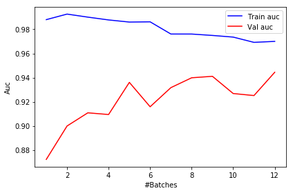

```python
import matplotlib.pyplot as plt

plt.plot(range(1, len(train_auc)+1), train_auc, color='blue', label='Train auc')
plt.plot(range(1, len(train_auc)+1), val_auc, color='red', label='Val auc')
plt.legend(loc="best")
plt.xlabel('#Batches')
plt.ylabel('Auc')
plt.tight_layout()
plt.savefig('./fig-out-of-core.png', dpi=300)
plt.show()
```

The learning curve looks great! The validation accuracy improves as more examples are seen.

Since training `SGDClassifier` may take long, you can save your trained classifier to disk periodically:

```python
# import optimized pickle written in C for serializing and  de-serializing a Python object
import _pickle as pkl

# dump to disk
pkl.dump(hashvec, open('hashvec.pkl', 'wb'))
pkl.dump(clf, open('clf-sgd.pkl', 'wb'))

# load from disk
hashvec = pkl.load(open('hashvec.pkl', 'rb'))
clf = pkl.load(open('clf-sgd.pkl', 'rb'))

df_test = pd.read_csv('imdb.csv')
print('test auc: %.3f' % roc_auc_score(df_test['sentiment'],
                                       clf.predict_proba(hashvec.transform(df_test['review']))[:,1]))
```

```
test auc: 0.948
```

Now you have the all the supporting knowledge for the competition. Happy coding and good luck!